# Transonic

```python
import numpy as np
import matplotlib.pyplot as plt
%matplotlib inline
```

Build all the functions we need to calculate the various terms as a function of radius

Equation (71) of Adams & Gregory (2012) for the co-ordinate q: \begin{equation} q=\frac{1}{\xi_d}\left(1-\frac{\Gamma}{4\xi_d^2}\right) \end{equation}

```python
def get_q_coord(xid,Gamma):
    q=1./xid*(1.-Gamma/(4.*xid**2.))

    return q
```

Also in the case that the truncation point is at the co-rotation radius the dimensionless angular velocity parameter ($\omega$) becomes $\omega=b\xi_d^{-3}$. So we can build a function to calculate this.

```python
def get_w(xid,b):
    w=b*xid**(-3.)
    return w
```

Now we wish to calculate $\cos^2\theta$ and $\sin^2\theta$ as a function of $\xi$, so from Equation (66) of Adams & Gregory (2012) we have: \begin{equation} \sin^2\theta=\frac{2}{5\Gamma}\left{(\xi^2+\Gamma)-\left[(\xi^2+\Gamma)^2-5\Gamma q\xi^3\right]^{1/2}\right} \end{equation}

```python
def get_trig_func(q,Gamma,xi):
    s2=2./(5.*Gamma)*((xi**2.+Gamma)-((xi**2.+Gamma)**2.-5.*Gamma*q*xi**3.)**0.5)
    c2=1.-s2

    return s2, c2
```

Now the ancillary functions $f$ and $g$ defined in Equations (67) and (68) of Adams & Gregory (2012): \begin{equation} f(\xi)=\Gamma(5\cos^2\theta-3)+2\xi^2 \end{equation} and, \begin{equation} g(\xi)=\frac{3}{4}\Gamma(5\cos^2\theta-1)+\xi^2 \end{equation}

```python
def get_f_g(q,Gamma,xi):

    s2,c2=get_trig_func(q,Gamma,xi)
    f=Gamma*(5.*c2-3.)+2.*xi**2.
    g=3./4.*Gamma*(5.*c2-1.)+xi**2.

    return f,g
```

We also need the derivative of $f$ with respect to $\xi$, using equation (67) of Adams of Gregory (2012), with; \begin{equation} f(\xi)=2\left[\left(\xi^2+\Gamma\right)^2-5\Gamma q\xi^3\right]^{1/2} \end{equation} we find: \begin{equation} \frac{{\rm d}f}{{\rm d}\xi}=\frac{4\xi(\xi^2+\Gamma)-15\Gamma q \xi^2}{\left[\left(\xi^2+\Gamma\right)^2-5\Gamma q\xi^3\right]^{1/2}} \end{equation}

```python
def get_df_dx(q,Gamma,xi):
    df_dx=(4.*xi*(xi**2.+Gamma)-15.*Gamma*q*xi**2.)/((xi**2.+Gamma)**2.-5.*Gamma*q*xi**3.)**0.5

    return df_dx
```

We also need the scale factor $h_p$ which from Equation (64) of Adams & Gregory (2012) is: \begin{equation} h_p=\xi^5\left[f^2\cos^2\theta+g^2\sin^2\theta\right]^{-1/2} \end{equation}

```python
def get_hp(q,Gamma,xi):
    f,g=get_f_g(q,Gamma,xi)
    s2,c2=get_trig_func(q,Gamma,xi)

    hp=xi**5./np.sqrt(f**2.*c2+g**2.*s2)

    return hp
```

Finally, we need the functions $\Lambda$ and $\Upsilon$ contained in Equations (69) and (70) of Adams & Gregory (2012):

```python
def get_lambda(xi,q,Gamma):
    f,g=get_f_g(q,Gamma,xi)

    L=2.*xi/(5.*Gamma)*((xi**2.+Gamma)-((xi**2.+Gamma)**2.-5.*Gamma*q*xi**3.)**0.5)*(1.+g/f)

    return L
```

```python
def get_up(q,Gamma,xi):
    f,g=get_f_g(q,Gamma,xi)
    fx=get_df_dx(q,Gamma,xi)

    BB=xi/(5.*Gamma)*(5*Gamma*f*fx+(g*(0.75*fx-xi)-f*fx)*(2.*xi**2.+2*Gamma-f)+(g**2.-f**2)*(2.*xi-0.5*fx))
    Y=5.-BB/(f**2.+(g**2.-f**2.)*(2.*xi**2.+2*Gamma-f)/(5.*Gamma))

    return Y
```

Now we can repoduce Figure 4 for $\Upsilon$ of Adams & Gregory (2012) as a test

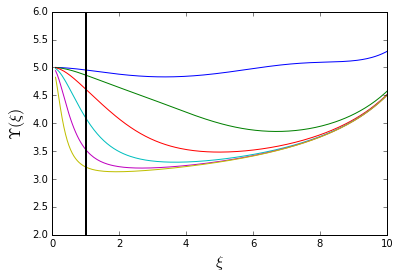

```python
Gamma=np.logspace(1.5,-1,6)
xid=10.
xi=np.linspace(0.1,xid,200)
for i in range(0,np.size(Gamma)):
    q=get_q_coord(xid,Gamma[i])
    Y=get_up(q,Gamma[i],xi)
    plt.plot(xi,Y)

plt.ylim((2,6))
plt.plot([1, 1],[2,6],'k',lw=2)
plt.xlabel(r'$\xi$',fontsize=16)
plt.ylabel(r'$\Upsilon(\xi)$',fontsize=16)
```

This agrees well with the plot in Adams & Gregory (2012). Since the calculation of $\Upsilon$ relies on most functions, expect that for $\Lambda$ is a good bet that they are correct. Now a second check is to calculate the location of the sonic point for the isothermal example with $b=500$ and $250$. So for the isothermal pure dipole case the sonic point criterion becomes (from Equation 41) of Adams & Gregory (2012): \begin{equation} 3\xi_s\frac{8-5q\xi_s}{4-3q\xi_s}-2b+3\omega q \xi_s^4=0=S(\xi_s) \end{equation} So we can plot $S$ in the range $[1,\xi_d]$ to graphically see the sonic points.

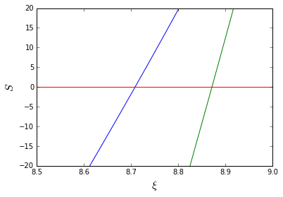

```python
xid=10.
b=[250.,500.]
xi=np.linspace(1,xid,500)
q=get_q_coord(xid,0.)

for i in range(0,np.size(b)):
    w=get_w(xid,b[i])
    S=3.*xi*(8.-5.*q*xi)/(4.-3.*q*xi)-2*b[i]+3.*w*q*xi**4.
    plt.plot(xi,S)

plt.xlim((8.5,9.))
plt.ylim((-20,20))
plt.plot([1, 10],[0,0])
plt.xlabel(r'$\xi$',fontsize=16)
plt.ylabel(r'$S$',fontsize=16)
```

In Connor's draft he states that the sonic point for $b=250$ is at 8.71 which looks write and the sonic point appears to be around 8.8/8.9 in Fred's plots. Now we can see what happens as $b$ becomes small. We can also look at the dominant terms in $S$ as a function of radius. Now for later note that the force equation is of the form: \begin{equation} \left(u-u^{-1}\right)\frac{{\rm d}u}{{\rm d}\xi}=S(\xi) \end{equation} in order to go through the sonic point with an inflow solution ${\rm d}u/{\rm d}\xi<0$. Now since $u<1$ at a distance slightly larger than the sonic point, this means $S(\xi+\epsilon)>0$, at a distance slightly smaller than the sonic point $u>1$, so $S(\xi-\epsilon)<0$, so a transonic solution also requires that: \begin{equation} \left.\frac{{\rm d}S(\xi)}{{\rm d}\xi}\right|_{\xi_s}>0. \end{equation}

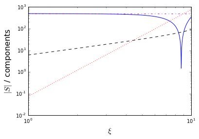

```python
xid=10.
b=[250.]
xi=np.linspace(1,xid,500)
q=get_q_coord(xid,0.)

for i in range(0,np.size(b)):
    w=get_w(xid,b[i])
    S=3.*xi*(8.-5.*q*xi)/(4.-3.*q*xi)-2*b[i]+3.*w*q*xi**4.
    plt.loglog(xi,abs(S))
    plt.loglog(xi,abs(3.*xi*(8.-5.*q*xi)/(4.-3.*q*xi)),'k--')
    plt.loglog(xi,3.*w*q*xi**4.,'r:')
    plt.loglog([1, 10],[2*b[i], 2*b[i]],'m-.')

plt.xlabel(r'$\xi$',fontsize=16)
plt.ylabel(r'$|S|$ / components',fontsize=16)
```

So it's clear when the sonic point occurs at large radius (i.e. if $b$ is large) then the balance is between gravity and the rotational term. So the sonic point simply becomes: \begin{equation} \xi_s^{4}=\frac{2}{3}\frac{b}{\omega q} \end{equation} but since $\omega=b\xi_d^{-3}$ this result is essentially independent of $b$. With \begin{equation} \xi_s=\left(\frac{2}{3}\right)^{1/4}\xi_d\sim0.9\xi_d \end{equation} as discussed by Adams & Gregory (2012).

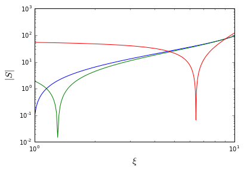

```python
xid=10.
b=[3.,4.,30]
xi=np.linspace(1,xid,500)
q=get_q_coord(xid,0.)
for i in range(0,np.size(b)):
    w=get_w(xid,b[i])
    S=3.*xi*(8.-5.*q*xi)/(4.-3.*q*xi)-2*b[i]+3.*w*q*xi**4.
    plt.loglog(xi,abs(S))

plt.plot([1, 10],[0,0])
plt.xlabel(r'$\xi$',fontsize=16)
plt.ylabel(r'$|S|$',fontsize=16)
```

Therefore, one sees that as $b\rightarrow0$ the sonic point moves closer and closer to to the star and if b becomes to small, graphically it looks like $b\lesssim 3$, then no-sonic point exists in the domain. Since we know $q$ is small and taking $xi_s\rightarrow 1$ the term containing $\omega$ becomes small and the fraction tends to $2$ so the sonic point condition does indeed give $b\approx 3$ as the limiting case. Now we can turn our attention to the full case.

In the full case, the sonic point criterion $S(\xi_s)$ can be written: \begin{equation} S'(\xi_s)=(n+\frac{1}{2})\left(\frac{b-\omega\Lambda(\xi_s)\xi_s^2}{\Upsilon(\xi_s)\xi_s}\right)-b(\xi_s^{-1}-\xi_d^{-1})-n-\omega[I(\xi_s)-I(\xi_d)]-\frac{1}{2}\left[\frac{h_p(\xi_s)}{h_p(\xi_d)}\right]^2\left(\frac{b-\omega\Lambda(\xi_s)\xi_s^2}{\Upsilon(\xi_s)\xi_s}\right)^{2n+1}=0 \end{equation} to calculate this we need to define a function that evaluates $I(b)-I(a)$.

Now remeber sonic point requires $S'(\xi_s)=0.$ and, \begin{equation} \left.\frac{{\rm d}S'}{{\rm d}\xi}\right|_{\xi_s}>0 \end{equation}

```python
from scipy.integrate import quad
def get_I(q,Gamma,a,b):
    I,err=quad(get_lambda,a,b,args=(q,Gamma))
    return I
```

Now we are in a position to look at the complete $S(\xi)$ as a function of $\xi$, so generate function to calculate $S(\xi)$.

```python
def get_full_S(b,n,q,xid,Gamma,xi):
    L=get_lambda(xi,q,Gamma) # remember get_lambda is specified in a form for the interfral with xi first!
    Y=get_up(q,Gamma,xi)
    hp=get_hp(q,Gamma,xi)
    hp_d=get_hp(q,Gamma,xid)
    w=get_w(xid,b)
    DeltaI=np.zeros(np.size(xi))
    if np.size(xi) > 1:
        for i in range(0,np.size(xi)):
            DeltaI[i]=-get_I(q,Gamma,xi[i],0.99999999*xid) # minus sign since limits are reversed
    else:
        DeltaI=-get_I(q,Gamma,xi,0.99999999*xid)

    S=(n+0.5)*((b-w*L*xi**2.)/(Y*xi))-b*(1./xi-1./xid)-n-w*(DeltaI)-0.5*(hp/hp_d)**2.*((b-w*L*xi**2.)/(Y*xi))**(2.*n+1.)

    return S
```

Now consider same problem as isothermal case, for $b=250$, $\xi_s\approx8.71$ with $\xi_d=10.$ and $\Gamma=0.$

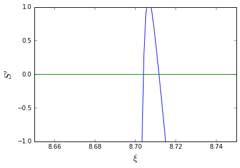

```python
xid=10.
b=250.
n=100.
Gamma=0.000001
q=get_q_coord(xid,Gamma)
xi=np.linspace(8.,xid-0.0001,2000)
S=get_full_S(b,n,q,xid,Gamma,xi)
plt.plot(xi,S)
plt.ylim(-1,1)
plt.xlim(8.65,8.75)
plt.plot([1, 10],[0,0])
plt.xlabel(r'$\xi$',fontsize=16)
plt.ylabel(r"$S'$",fontsize=16)
```

Therefore, we see as expected the solution with ${\rm d}S'/{\rm d}\xi>0$ has a value of order 8.71. We can see what happens as $n$ is reduced.

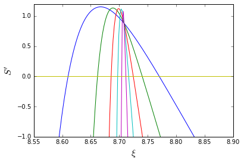

```python
xid=10.
b=250.
n=[5.,10.,20.,40.,100.]
Gamma=0.000001
q=get_q_coord(xid,Gamma)
xi=np.linspace(6.,xid-0.0001,2000)
for i in range(0,np.size(n)):
    S=get_full_S(b,n[i],q,xid,Gamma,xi)
    plt.plot(xi,S)

plt.ylim(-1,1.2)
plt.xlim(8.55,8.9)
plt.plot([1, 10],[0,0])
plt.xlabel(r'$\xi$',fontsize=16)
plt.ylabel(r"$S'$",fontsize=16)
```

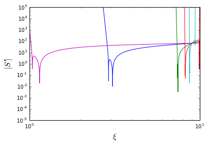

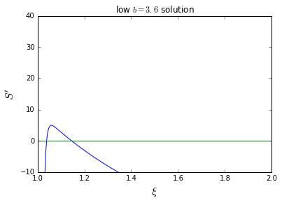

```python
xid=10.
b=[10., 50., 100., 250., 3.6]
n=67.
Gamma=0.000001
q=get_q_coord(xid,Gamma)
xi=np.linspace(1.,xid-0.0001,5000)
for i in range(0,np.size(b)):
    S=get_full_S(b[i],n,q,xid,Gamma,xi)
    plt.loglog(xi,abs(S))

plt.ylim(1e-5,1e5)
plt.plot([1, 10],[0,0])
plt.xlabel(r'$\xi$',fontsize=16)
plt.ylabel(r"$|S'|$",fontsize=16)

plt.figure()
plt.title(r'low $b=3.6$ solution')
plt.plot(xi,S)
plt.ylim(-10,40)
plt.xlim(1.,2.)
plt.plot([1, 10],[0,0])
plt.xlabel(r'$\xi$',fontsize=16)
plt.ylabel(r"$S'$",fontsize=16)
```

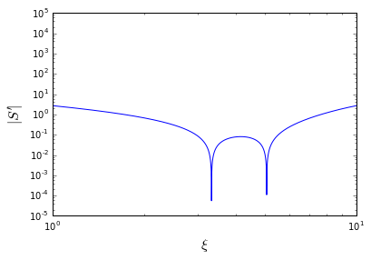

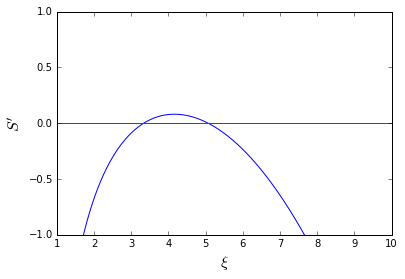

```python
xid=10.
b=25.
n=2.
Gamma=0.000001
q=get_q_coord(xid,Gamma)
xi=np.linspace(1.,xid-0.0001,5000)
for i in range(0,np.size(b)):
    S=get_full_S(b,n,q,xid,Gamma,xi)
    plt.loglog(xi,abs(S))

plt.ylim(1e-5,1e5)
plt.plot([1, 10],[0,0])
plt.xlabel(r'$\xi$',fontsize=16)
plt.ylabel(r"$|S'|$",fontsize=16)

plt.figure()
plt.plot(xi,S)
plt.ylim(-1,1.)
plt.xlim(1.,10.)
plt.plot([1, 10],[0,0])
plt.xlabel(r'$\xi$',fontsize=16)
plt.ylabel(r"$S'$",fontsize=16)
```

At very low $n$, the last sonic point is no longer at $\xi=1$ and vanishes in the middle of the domain. For the times we know the last sonic point is at $\xi=1$, we can numerically solve for the minimum $b$ as a function of $n$ for fixed $\Gamma$ and $\xi_d$.

```python
from scipy.optimize import root
from scipy.optimize import brentq
```

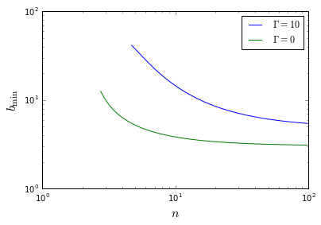

```python
xid=10.
Gamma=10.
q=get_q_coord(xid,Gamma)
N=np.logspace(2,np.log10(4.7),250)
guess=10.
tolerance=1e-13 # need to have explict control of this
sol=np.zeros(np.size(N))
for i in range(0,np.size(N)):
    n=N[i]
    bmin=root(get_full_S,guess,args=(n,q,xid,Gamma,1.),tol=tolerance)
    Sh=get_full_S(bmin.x,n,q,xid,Gamma,1.+3.*tolerance)
    if Sh < 0.:
        # reject solution as incorrect root
        # fist check S(bmin+10.*tol) > 0.
        if get_full_S(bmin.x+10.*tolerance,n,q,xid,Gamma,1.) > 0:
            index=1
            A=bmin.x+10.*tolerance
            while index < 10:
                B=3.**(index)*bmin.x
                if get_full_S(B,n,q,xid,Gamma,1.) < 0:
                    # sign change can use interval solver
                    bmin=brentq(get_full_S,A,B,args=(n,q,xid,Gamma,1.),xtol=tolerance)
                    sol[i]=bmin
                    break
                index=index+1
            if index==20:
                print "Failed to find correct root with n=", n
    else:
        sol[i]=bmin.x
    guess=sol[i]
plt.loglog(N,sol,label=r'$\Gamma=10$')
Gamma=0.00001
q=get_q_coord(xid,Gamma)
N2=np.logspace(2,np.log10(2.75),250)
guess=10.
tolerance=1e-13 # need to have explict control of this
sol2=np.zeros(np.size(N))
for i in range(0,np.size(N)):
    n=N2[i]
    bmin=root(get_full_S,guess,args=(n,q,xid,Gamma,1.),tol=tolerance)
    Sh=get_full_S(bmin.x,n,q,xid,Gamma,1.+3.*tolerance)
    if Sh < 0.:
        # reject solution as incorrect root
        # fist check S(bmin+10.*tol) > 0.
        if get_full_S(bmin.x+10.*tolerance,n,q,xid,Gamma,1.) > 0:
            index=1
            A=bmin.x+10.*tolerance
            while index < 10:
                B=3.**(index)*bmin.x
                if get_full_S(B,n,q,xid,Gamma,1.) < 0:
                    # sign change can use interval solver
                    bmin=brentq(get_full_S,A,B,args=(n,q,xid,Gamma,1.),xtol=tolerance)
                    sol2[i]=bmin
                    break
                index=index+1
            if index==20:
                print "Failed to find correct root with n=", n
    else:
        sol2[i]=bmin.x
    guess=sol2[i]
plt.loglog(N2,sol2,label=r'$\Gamma=0$')
plt.xlabel(r'$n$',fontsize=16)
plt.ylabel(r'$b_{\rm min}$',fontsize=16)
plt.legend()
```